# 432 Lab 03

Steven Mayher

2022-02-14

## Package Loading

```r
library(conflicted)
library(here)
library(magrittr)
library(janitor)
library(naniar)
library(tableone)
library(patchwork)
library(knitr)
library(broom)
library(rms)
library(equatiomatic)
library(tidyverse)

theme_set(theme_bw())
conflict_prefer("summarize", "dplyr") # choose over Hmisc
conflict_prefer("filter", "dplyr") # choose over stats
```

## Import the `hbp3456` Data

```r
lab03 <- read_csv(here("data", "hbp3456.csv")) %>%
    mutate(record = as.character(record))
```

# 1 Part A

The following code filters the `hbp3456` data as instructed for the first part of this lab:

```r
part_a = lab03 %>%
  filter(practice == "Center" |
           practice == "Elm" |
           practice == "Plympton" |
           practice == "Walnut") %>%
  filter(complete.cases(ldl))
```

## 1.1 Question 1

The following code generates the two logistic regression models requested for this question, with `mod_q1` including the interaction term, and `mod_q1_no` not including the interaction term:

```r
mod_q1 = glm(statin == "Yes" ~ ldl * practice + rcs(age, 4), data = part_a, family = binomial(link = "logit"))

mod_q1_no = glm(statin == "Yes" ~ ldl + practice + rcs(age, 4), data = part_a, family = binomial(link = "logit"))
```

The coefficients for `mod_q1` are as follows:

```r
tidy(mod_q1, conf.int = TRUE, conf.level = 0.90) %>%
    select(term, estimate,
           low90 = conf.low, high90 = conf.high,
           se = std.error, p = p.value) %>%
    kable(digits = c(0,3,3,3,3,3))
```

| term | estimate | low90 | high90 | se | p |
| --- | --- | --- | --- | --- | --- |
| (Intercept) | -1.764 | -3.045 | -0.514 | 0.768 | 0.022 |
| ldl | -0.009 | -0.014 | -0.005 | 0.003 | 0.001 |
| practiceElm | 1.237 | 0.377 | 2.107 | 0.526 | 0.019 |
| practicePlympton | -1.938 | -2.910 | -0.976 | 0.587 | 0.001 |
| practiceWalnut | -1.244 | -2.065 | -0.431 | 0.496 | 0.012 |
| rcs(age, 4)age | 0.053 | 0.030 | 0.078 | 0.015 | 0.000 |
| rcs(age, 4)age’ | 0.004 | -0.039 | 0.047 | 0.026 | 0.869 |
| rcs(age, 4)age’’ | -0.235 | -0.497 | 0.027 | 0.159 | 0.139 |
| ldl:practiceElm | -0.011 | -0.019 | -0.004 | 0.005 | 0.015 |
| ldl:practicePlympton | 0.005 | -0.002 | 0.012 | 0.004 | 0.256 |
| ldl:practiceWalnut | 0.013 | 0.006 | 0.020 | 0.004 | 0.002 |

The coefficients for `mod_q1_no` are as follows:

```r
tidy(mod_q1_no, conf.int = TRUE, conf.level = 0.90) %>%
    select(term, estimate,
           low90 = conf.low, high90 = conf.high,
           se = std.error, p = p.value) %>%
    kable(digits = c(0,3,3,3,3,3))
```

| term | estimate | low90 | high90 | se | p |
| --- | --- | --- | --- | --- | --- |
| (Intercept) | -1.972 | -3.137 | -0.844 | 0.696 | 0.005 |
| ldl | -0.007 | -0.010 | -0.005 | 0.002 | 0.000 |
| practiceElm | 0.122 | -0.150 | 0.394 | 0.165 | 0.461 |
| practicePlympton | -1.312 | -1.629 | -1.001 | 0.191 | 0.000 |
| practiceWalnut | 0.239 | -0.010 | 0.488 | 0.152 | 0.116 |
| rcs(age, 4)age | 0.052 | 0.029 | 0.076 | 0.014 | 0.000 |
| rcs(age, 4)age’ | 0.005 | -0.038 | 0.048 | 0.026 | 0.845 |
| rcs(age, 4)age’’ | -0.231 | -0.489 | 0.026 | 0.157 | 0.139 |

## 1.2 Question 2

Although already given in the answer to the previous question, the coefficients and 90% confidence interval for the model without an interaction term (`mod_q1_no`) has been provided again below, both in the same manner as above and also provided with the `summary` function:

```r
tidy(mod_q1_no, exponentiate = TRUE, conf.int = TRUE, conf.level = 0.90) %>%
    filter(term == "ldl") %>%
    select(term, estimate,
           low90 = conf.low, high90 = conf.high,
           se = std.error, p = p.value) %>%
    kable(digits = c(0,3,3,3,3,3))
```

| term | estimate | low90 | high90 | se | p |
| --- | --- | --- | --- | --- | --- |
| ldl | 0.993 | 0.99 | 0.995 | 0.002 | 0 |

```r
summary(mod_q1_no, conf.int = 0.9)
```

```
Call:
glm(formula = statin == "Yes" ~ ldl + practice + rcs(age, 4),
    family = binomial(link = "logit"), data = part_a)

Deviance Residuals:
    Min       1Q   Median       3Q      Max
-1.7802  -1.0692   0.7039   0.9871   2.1350

Coefficients:
                  Estimate Std. Error z value Pr(>|z|)
(Intercept)      -1.971816   0.696256  -2.832 0.004625 **
ldl              -0.007098   0.001519  -4.673 2.97e-06 ***
practiceElm       0.121815   0.165203   0.737 0.460900
practicePlympton -1.312311   0.190778  -6.879 6.04e-12 ***
practiceWalnut    0.238511   0.151580   1.573 0.115604
rcs(age, 4)age    0.052075   0.014343   3.631 0.000283 ***
rcs(age, 4)age'   0.005081   0.025971   0.196 0.844888
rcs(age, 4)age'' -0.231482   0.156610  -1.478 0.139386
---
Signif. codes:  0 '***' 0.001 '**' 0.01 '*' 0.05 '.' 0.1 ' ' 1

(Dispersion parameter for binomial family taken to be 1)

    Null deviance: 2003.1  on 1445  degrees of freedom
Residual deviance: 1801.1  on 1438  degrees of freedom
AIC: 1817.1

Number of Fisher Scoring iterations: 4
```

```r
exp(coef(mod_q1_no))
```

```
     (Intercept)              ldl      practiceElm practicePlympton
       0.1392038        0.9929273        1.1295453        0.2691973
  practiceWalnut   rcs(age, 4)age  rcs(age, 4)age' rcs(age, 4)age''
       1.2693571        1.0534548        1.0050940        0.7933571
```

From the above we can see that, if all other predictors are equal as suggested between our two examples of Harry and Sally, then a 1 unit increase in `ldl` increases the odds of taking a statin by a factor of 0.993.

## 1.3 Question 3

Although already given in the answer to the previous question, the coefficients and 90% confidence interval for the model with an interaction term (`mod_q1`) has been provided again below, both in the same manner as above and also provided with the `summary` function:

```r
tidy(mod_q1, exponentiate = TRUE, conf.int = TRUE, conf.level = 0.90) %>%
    filter(term == "ldl") %>%
    select(term, estimate,
           low90 = conf.low, high90 = conf.high,
           se = std.error, p = p.value) %>%
    kable(digits = c(0,3,3,3,3,3))
```

| term | estimate | low90 | high90 | se | p |
| --- | --- | --- | --- | --- | --- |
| ldl | 0.991 | 0.986 | 0.995 | 0.003 | 0.001 |

```r
summary(mod_q1, conf.int = 0.9)
```

```
Call:
glm(formula = statin == "Yes" ~ ldl * practice + rcs(age, 4),
    family = binomial(link = "logit"), data = part_a)

Deviance Residuals:
    Min       1Q   Median       3Q      Max
-2.0805  -1.0256   0.5583   0.9849   2.1593

Coefficients:
                      Estimate Std. Error z value Pr(>|z|)
(Intercept)          -1.763911   0.768493  -2.295 0.021717 *
ldl                  -0.009392   0.002928  -3.208 0.001337 **
practiceElm           1.236967   0.525589   2.353 0.018598 *
practicePlympton     -1.937782   0.587376  -3.299 0.000970 ***
practiceWalnut       -1.244010   0.496264  -2.507 0.012185 *
rcs(age, 4)age        0.053241   0.014507   3.670 0.000242 ***
rcs(age, 4)age'       0.004355   0.026319   0.165 0.868561
rcs(age, 4)age''     -0.235012   0.159038  -1.478 0.139485
ldl:practiceElm      -0.011167   0.004581  -2.438 0.014782 *
ldl:practicePlympton  0.004879   0.004296   1.136 0.256066
ldl:practiceWalnut    0.012959   0.004112   3.152 0.001624 **
---
Signif. codes:  0 '***' 0.001 '**' 0.01 '*' 0.05 '.' 0.1 ' ' 1

(Dispersion parameter for binomial family taken to be 1)

    Null deviance: 2003.1  on 1445  degrees of freedom
Residual deviance: 1770.0  on 1435  degrees of freedom
AIC: 1792

Number of Fisher Scoring iterations: 4
```

```r
exp(coef(mod_q1))
```

```
         (Intercept)                  ldl          practiceElm
           0.1713732            0.9906523            3.4451473
    practicePlympton       practiceWalnut       rcs(age, 4)age
           0.1440230            0.2882262            1.0546843
     rcs(age, 4)age'     rcs(age, 4)age''      ldl:practiceElm
           1.0043650            0.7905612            0.9888947
ldl:practicePlympton   ldl:practiceWalnut
           1.0048910            1.0130433
```

## 1.4 Question 4

# 2 Part B

```r
set.seed(432)

hbp_b = lab03 %>%
  filter(complete.cases(hsgrad, income)) %>%
  select(c("record", "income", "hsgrad", "race", "eth_hisp", "age", "tobacco")) %>%
  mutate(sqrtinc = sqrt(income)) %>%
  mutate(income = as.integer(income)) %>%
  mutate(race = as.factor(race)) %>%
  mutate(eth_hisp = as.factor(eth_hisp)) %>%
  mutate(age = as.integer(age)) %>%
  mutate(tobacco = as.factor(tobacco)) %>%
  slice_sample(n = 1000)

hbp_b
```

```
# A tibble: 1,000 x 8
   record income hsgrad race     eth_hisp   age tobacco sqrtinc
   <chr>   <int>  <dbl> <fct>    <fct>    <int> <fct>     <dbl>
 1 903574  34800   94.9 White    No          48 Current    187.
 2 926837  24700   74.2 AA_Black No          55 Current    157.
 3 929198  14700   40   AA_Black No          35 Never      121.
 4 932367  24700   74.2 AA_Black No          41 Never      157.
 5 925592  65600   92.2 <NA>     <NA>        61 Never      256.
 6 932404  18500   67.8 AA_Black No          67 Never      136.
 7 933953  21500   84.4 White    No          72 Never      147.
 8 911527  23000   83.6 White    No          62 Never      152.
 9 918228  13400   70.3 AA_Black No          52 Current    116.
10 930262  48300   90   <NA>     <NA>        73 Never      220.
# ... with 990 more rows
```

## 2.1 Question 5

As can be seen below, there’s 37 missing values in `eth_hisp`, 31 missing values in `race`, and 2 missing values in `tobacco`:

```r
miss_var_summary(hbp_b)
```

```
# A tibble: 8 x 3
  variable n_miss pct_miss
  <chr>     <int>    <dbl>
1 eth_hisp     37      3.7
2 race         31      3.1
3 tobacco       2      0.2
4 record        0      0
5 income        0      0
6 hsgrad        0      0
7 age           0      0
8 sqrtinc       0      0
```

## 2.2 Question 6

The code below generates the Spearman ρ2 plot:

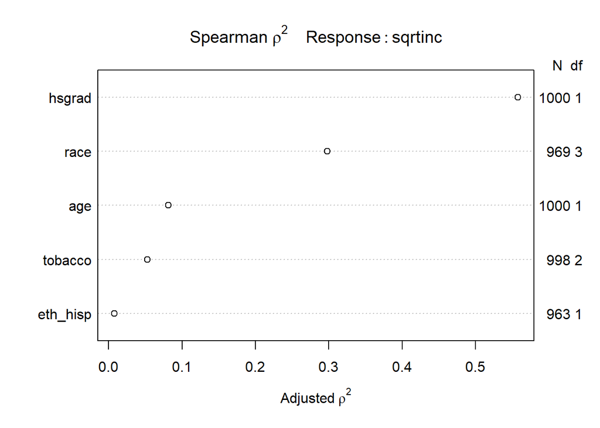

```r
spear_hbp_b = spearman2(sqrtinc ~ eth_hisp + race + tobacco + age + hsgrad, data = hbp_b)
plot(spear_hbp_b)
```

From the plot above, the single non-linear term that adds exactly two degrees of freedom is the `hsgrad` variable, and thus would make the best choice that adds two degrees of freedom.

## 2.3 Question 7

The code necessary for creating the model `m1` and it’s associated ANOVA and effects summary plot have been provided in the following few chunks:

```r
dd <- datadist(hbp_b)
options(datadist = "dd")

m1 = ols(sqrtinc ~ hsgrad + race + age + tobacco + eth_hisp, data = hbp_b, x = TRUE, y = TRUE)
```

```r
anova(m1)
```

```
                Analysis of Variance          Response: sqrtinc

 Factor     d.f. Partial SS MS          F      P
 hsgrad       1   518557.08 518557.0751 640.19 <.0001
 race         3   230265.61  76755.2025  94.76 <.0001
 age          1     3468.92   3468.9196   4.28 0.0388
 tobacco      2    10937.67   5468.8366   6.75 0.0012
 eth_hisp     1    12184.08  12184.0839  15.04 0.0001
 REGRESSION   8  1272864.01 159108.0016 196.43 <.0001
 ERROR      947   767080.00    810.0106
```

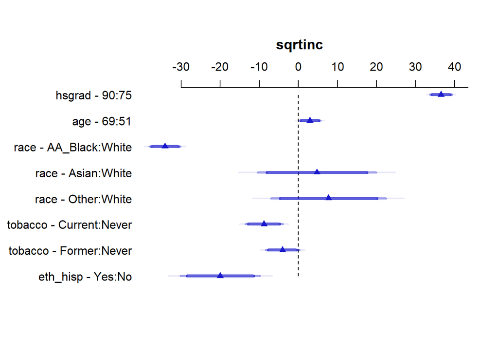

```r
plot(summary(m1))
```

```r
summary(m1, conf.int = 0.9)
```

```
             Effects              Response : sqrtinc

 Factor                  Low High Diff. Effect   S.E.   Lower 0.9 Upper 0.9
 hsgrad                  75  90   15     36.5110 1.4430  34.13500  38.8870
 age                     51  69   18      2.9133 1.4078   0.59545   5.2312
 race - AA_Black:White    4   1   NA    -34.1710 2.0531 -37.55100 -30.7900
 race - Asian:White       4   2   NA      4.7215 7.7590  -8.05340  17.4960
 race - Other:White       4   3   NA      7.6981 7.5363  -4.71010  20.1060
 tobacco - Current:Never  3   1   NA     -8.8151 2.4329 -12.82100  -4.8094
 tobacco - Former:Never   3   2   NA     -4.0765 2.1927  -7.68670  -0.4663
 eth_hisp - Yes:No        1   2   NA    -20.0290 5.1643 -28.53200 -11.5260
```

## 2.4 Question 8

```r
dd <- datadist(hbp_b)
options(datadist = "dd")

m2 = ols(sqrtinc ~ rcs(hsgrad, 4) + race + age + tobacco + eth_hisp, data = hbp_b, x = TRUE, y = TRUE)
```

```r
anova(m2)
```

```
                Analysis of Variance          Response: sqrtinc

 Factor     d.f. Partial SS  MS          F      P
 hsgrad       3   623155.151 207718.3836 296.30 <.0001
  Nonlinear   2   104598.076  52299.0378  74.60 <.0001
 race         3   192414.029  64138.0098  91.49 <.0001
 age          1     3773.850   3773.8499   5.38 0.0205
 tobacco      2     7196.034   3598.0171   5.13 0.0061
 eth_hisp     1     7961.648   7961.6481  11.36 0.0008
 REGRESSION  10  1377462.088 137746.2088 196.49 <.0001
 ERROR      945   662481.920    701.0391
```

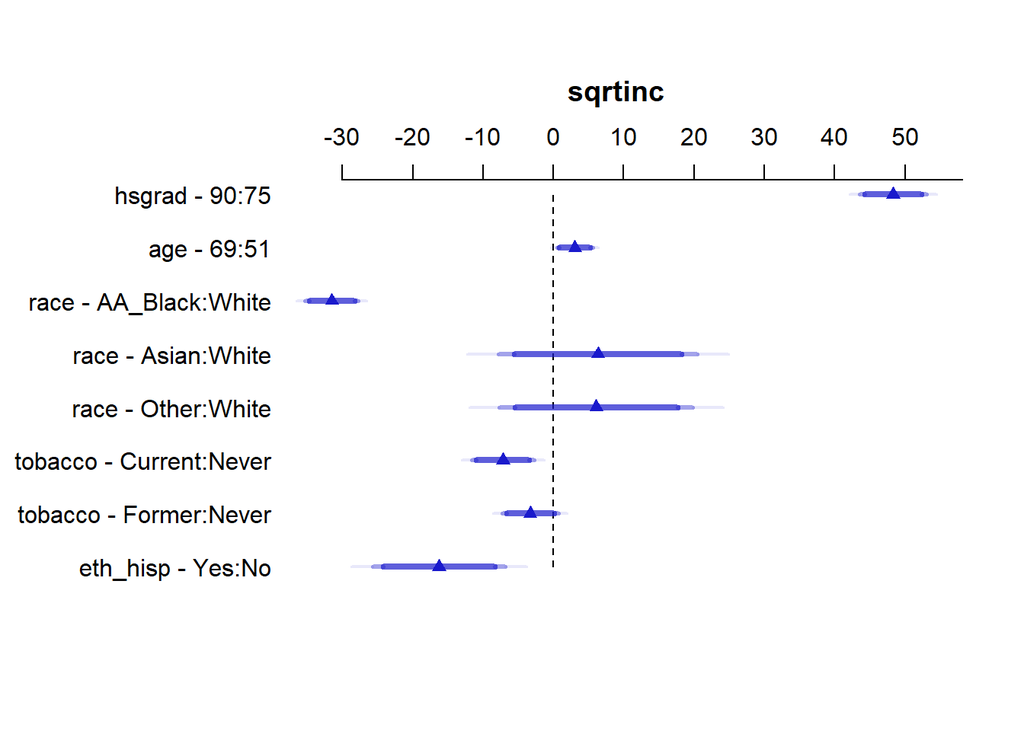

```r
plot(summary(m2))
```

```r
summary(m2)
```

```
             Effects              Response : sqrtinc

 Factor                  Low High Diff. Effect   S.E.   Lower 0.95 Upper 0.95
 hsgrad                  75  90   15     48.3070 2.4115  43.57400   53.03900
 age                     51  69   18      3.0463 1.3130   0.46965    5.62300
 race - AA_Black:White    4   1   NA    -31.5260 1.9326 -35.31900  -27.73400
 race - Asian:White       4   2   NA      6.3252 7.2269  -7.85740   20.50800
 race - Other:White       4   3   NA      6.0740 7.0130  -7.68880   19.83700
 tobacco - Current:Never  3   1   NA     -7.1800 2.2710 -11.63700   -2.72320
 tobacco - Former:Never   3   2   NA     -3.3102 2.0456  -7.32460    0.70421
 eth_hisp - Yes:No        1   2   NA    -16.2770 4.8300 -25.75600   -6.79840
```

## 2.5 Question 9

Unfortunately, I was unable to determine how to aggregate the results into one single table, however the uncorrected raw R^2, AIC, and BIC values for model `m1` have been provided below along with the model’s validated R^2 and MSE values:

```r
set.seed(2022)

validate(m1, method = "boot", B = 40)
```

```
          index.orig training     test optimism index.corrected  n
R-square      0.6240   0.6289   0.6209   0.0080          0.6159 40
MSE         802.3849 795.9224 808.9716 -13.0493        815.4342 40
g            41.4623  41.7371  41.3782   0.3589         41.1033 40
Intercept     0.0000   0.0000   1.1044  -1.1044          1.1044 40
Slope         1.0000   1.0000   0.9940   0.0060          0.9940 40
```

```r
m1 = lm(sqrtinc ~ hsgrad + race + age + tobacco + eth_hisp, data = hbp_b, x = TRUE, y = TRUE)


glance(m1) %>%
  select(r.squared, AIC, BIC) %>%
  kable(digits = c(3, 1, 1))
```

| r.squared | AIC | BIC |
| --- | --- | --- |
| 0.624 | 9126.3 | 9175 |

And the following code provides the same for model `m2`:

```r
set.seed(2022)

validate(m2, method = "boot", B = 40)
```

```
          index.orig training     test optimism index.corrected  n
R-square      0.6752   0.6781   0.6718   0.0063          0.6689 40
MSE         692.9727 690.3871 700.3531  -9.9659        702.9387 40
g            43.7609  43.9729  43.6668   0.3061         43.4548 40
Intercept     0.0000   0.0000   1.3042  -1.3042          1.3042 40
Slope         1.0000   1.0000   0.9932   0.0068          0.9932 40
```

```r
m2 = lm(sqrtinc ~ rcs(hsgrad, 4) + race + age + tobacco + eth_hisp, data = hbp_b, x = TRUE, y = TRUE)


glance(m2) %>%
  select(r.squared, AIC, BIC) %>%
  kable(digits = c(3, 1, 1))
```

| r.squared | AIC | BIC |
| --- | --- | --- |
| 0.675 | 8990.2 | 9048.6 |

By reviewing the above metrics, it appears that `m2` represents a better fit than `m1`, as `m2` appears to have outperformed `m1` in all of the above metrics.

# 3 Part C

## 3.1 Question 10

One important thing I learned from Nate Silver’s “The Signal and the Noise” is the importance of thinking probabilistically. To be fair, this is not exactly a new concept at this point to me, as this has been heavily emphasized throughout 431 and 432. However, the importance of this concept cannot be overstated, and neither can it’s execution. Nate Silver’s discussion of November 2010 U.S. House election results illustrated the importance of this concept in real-world practice. In particular, he demonstrated how the employment of a something as simple as a probability bell-curve can be far more useful than any simple remarks or statements for conveying the probable outcomes of the elections, and while this is a rather fundamental tool for statistical analysis, it should not be underestimated or understated. I will continue to employ and further develop this manner of thinking when approaching labs and the upcoming projects in this course to improve the accuracy of my reports, and beyond this course the accuracy of my research projects both here at Case and elsewhere.